# R/RStudio Training Session 4: Basic Statistics

# 3 Linear Regression

## 3.1 Fitting the Model

```r
library(car) ## Companion to Applied Regression
head(mtcars)
```

```
##                    mpg cyl disp  hp drat    wt  qsec vs am gear carb
## Mazda RX4         21.0   6  160 110 3.90 2.620 16.46  0  1    4    4
## Mazda RX4 Wag     21.0   6  160 110 3.90 2.875 17.02  0  1    4    4
## Datsun 710        22.8   4  108  93 3.85 2.320 18.61  1  1    4    1
## Hornet 4 Drive    21.4   6  258 110 3.08 3.215 19.44  1  0    3    1
## Hornet Sportabout 18.7   8  360 175 3.15 3.440 17.02  0  0    3    2
## Valiant           18.1   6  225 105 2.76 3.460 20.22  1  0    3    1
```

```r
str(mtcars)
```

```
## 'data.frame':    32 obs. of  11 variables:
##  $ mpg : num  21 21 22.8 21.4 18.7 18.1 14.3 24.4 22.8 19.2 ...
##  $ cyl : num  6 6 4 6 8 6 8 4 4 6 ...
##  $ disp: num  160 160 108 258 360 ...
##  $ hp  : num  110 110 93 110 175 105 245 62 95 123 ...
##  $ drat: num  3.9 3.9 3.85 3.08 3.15 2.76 3.21 3.69 3.92 3.92 ...
##  $ wt  : num  2.62 2.88 2.32 3.21 3.44 ...
##  $ qsec: num  16.5 17 18.6 19.4 17 ...
##  $ vs  : num  0 0 1 1 0 1 0 1 1 1 ...
##  $ am  : num  1 1 1 0 0 0 0 0 0 0 ...
##  $ gear: num  4 4 4 3 3 3 3 4 4 4 ...
##  $ carb: num  4 4 1 1 2 1 4 2 2 4 ...
```

```r
table(mtcars$vs) ## categorical
```

```
##
##  0  1
## 18 14
```

```r
fit <- lm(mpg ~ hp + wt + hp * wt + factor(vs), data=mtcars)
```

An object of class “lm” is a list containing the following components:

```r
names(fit)
```

```
##  [1] "coefficients"  "residuals"     "effects"       "rank"
##  [5] "fitted.values" "assign"        "qr"            "df.residual"
##  [9] "contrasts"     "xlevels"       "call"          "terms"
## [13] "model"
```

```r
fit$coefficients
```

```
## (Intercept)          hp          wt factor(vs)1       hp:wt
## 48.12210656 -0.11351174 -8.06322299  1.08776516  0.02736279
```

Print summary:

```r
summary(fit)
```

```
##
## Call:
## lm(formula = mpg ~ hp + wt + hp * wt + factor(vs), data = mtcars)
##
## Residuals:
##     Min      1Q  Median      3Q     Max
## -3.3660 -1.5110  0.0021  1.4956  4.4479
##
## Coefficients:
##              Estimate Std. Error t value Pr(>|t|)
## (Intercept) 48.122107   4.010530  11.999 2.49e-12 ***
## hp          -0.113512   0.025655  -4.425 0.000143 ***
## wt          -8.063223   1.281184  -6.294 9.80e-07 ***
## factor(vs)1  1.087765   1.127463   0.965 0.343212
## hp:wt        0.027363   0.007446   3.675 0.001039 **
## ---
## Signif. codes:  0 '***' 0.001 '**' 0.01 '*' 0.05 '.' 0.1 ' ' 1
##
## Residual standard error: 2.155 on 27 degrees of freedom
## Multiple R-squared:  0.8886, Adjusted R-squared:  0.8721
## F-statistic: 53.84 on 4 and 27 DF,  p-value: 1.764e-12
```

Print ANOVA tables:

```r
anova(fit) ##  Type I SS (sequential)
```

```
## Analysis of Variance Table
##
## Response: mpg
##            Df Sum Sq Mean Sq  F value    Pr(>F)
## hp          1 678.37  678.37 146.0180 2.116e-12 ***
## wt          1 252.63  252.63  54.3772 6.226e-08 ***
## factor(vs)  1   6.87    6.87   1.4783  0.234561
## hp:wt       1  62.74   62.74  13.5052  0.001039 **
## Residuals  27 125.44    4.65
## ---
## Signif. codes:  0 '***' 0.001 '**' 0.01 '*' 0.05 '.' 0.1 ' ' 1
```

```r
Anova(fit, type="III")  ### Type III SS (partial)
```

```
## Anova Table (Type III tests)
##
## Response: mpg
##             Sum Sq Df  F value    Pr(>F)
## (Intercept) 668.88  1 143.9745 2.487e-12 ***
## hp           90.95  1  19.5766 0.0001428 ***
## wt          184.02  1  39.6090 9.798e-07 ***
## factor(vs)    4.32  1   0.9308 0.3432124
## hp:wt        62.74  1  13.5052 0.0010389 **
## Residuals   125.44 27
## ---
## Signif. codes:  0 '***' 0.001 '**' 0.01 '*' 0.05 '.' 0.1 ' ' 1
```

Print Confidence Intervals for model parameters:

```r
confint(fit, level=0.95)
```

```
##                    2.5 %      97.5 %
## (Intercept)  39.89317861 56.35103450
## hp           -0.16615149 -0.06087199
## wt          -10.69199565 -5.43445034
## factor(vs)1  -1.22559812  3.40112844
## hp:wt         0.01208532  0.04264027
```

## 3.2 Commonly used functions with an “lm” object

- summary(fit) ——- results summary
- coefficients(fit) ——- model coefficients
- confint(fit, level=0.95) ——- CIs for model parameters
- fitted(fit) ——- predicted values
- residuals(fit) ——- residuals
- anova(fit) ——- type I ANOVA table
- Anova(fit,type=“III”) ——- type II or type III ANOVA table
- vcov(fit) ——- covariance matrix for model parameters
- influence(fit) ——- regression diagnostics

## 3.3 Diagnostic Plots

Diagnostic plots provide checks for heteroscedasticity, normality, and influential observerations.

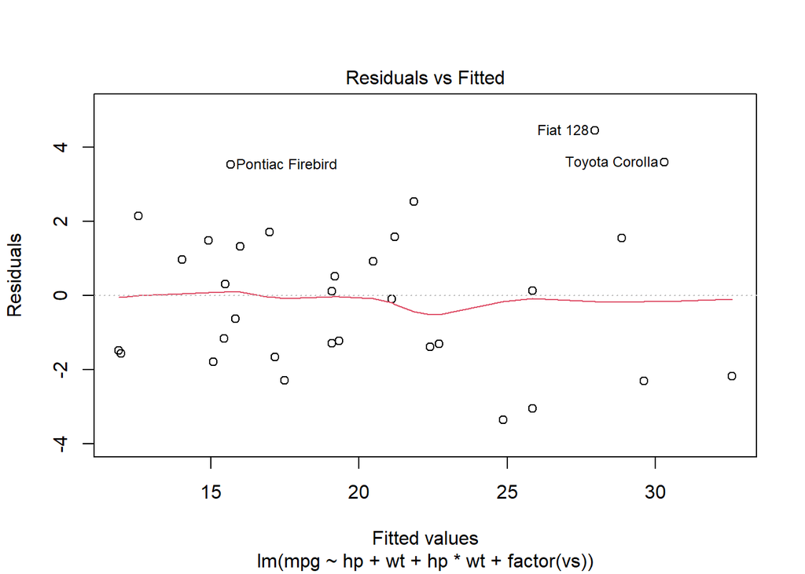

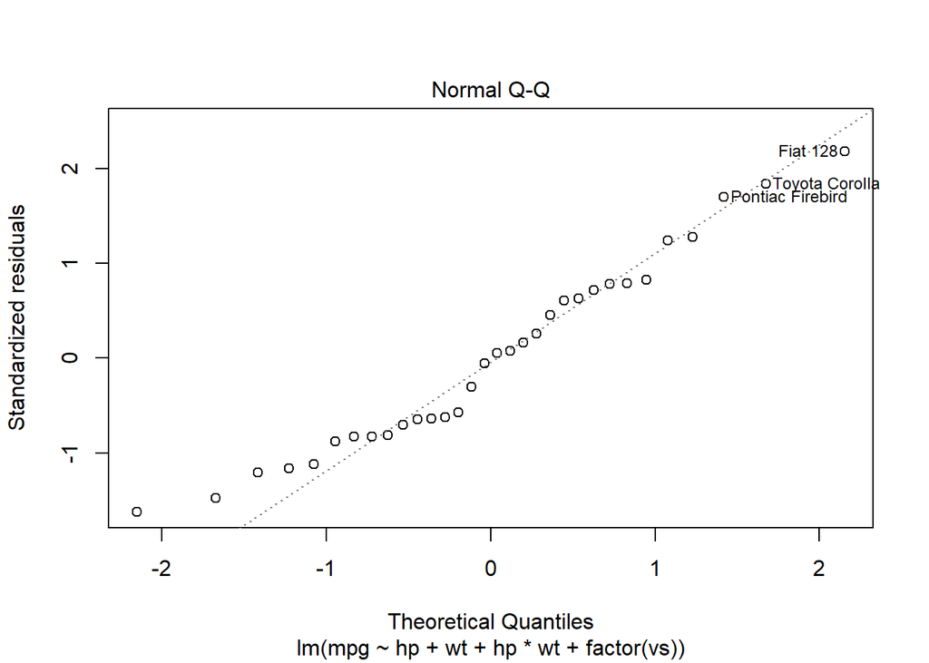

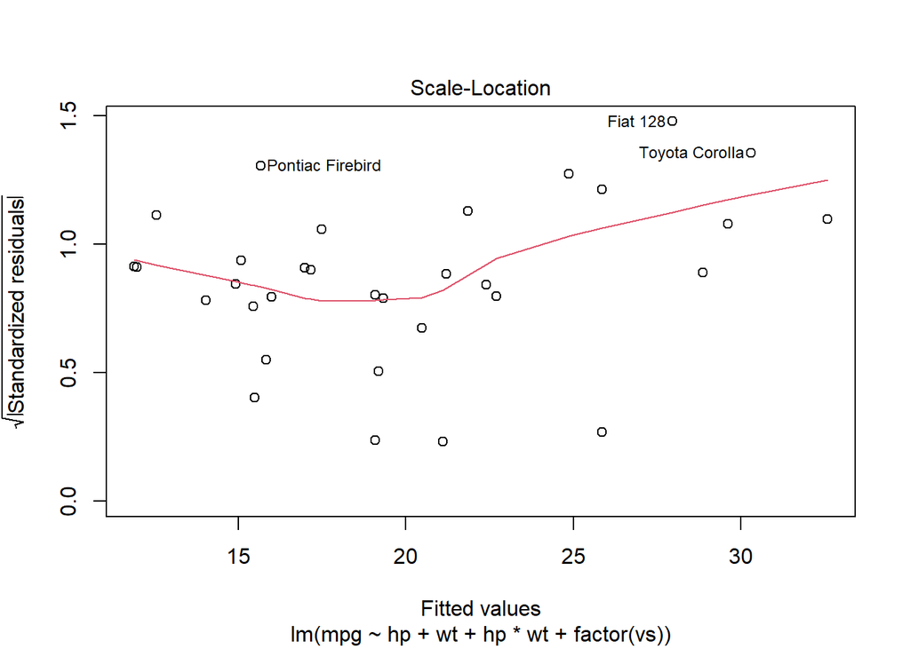

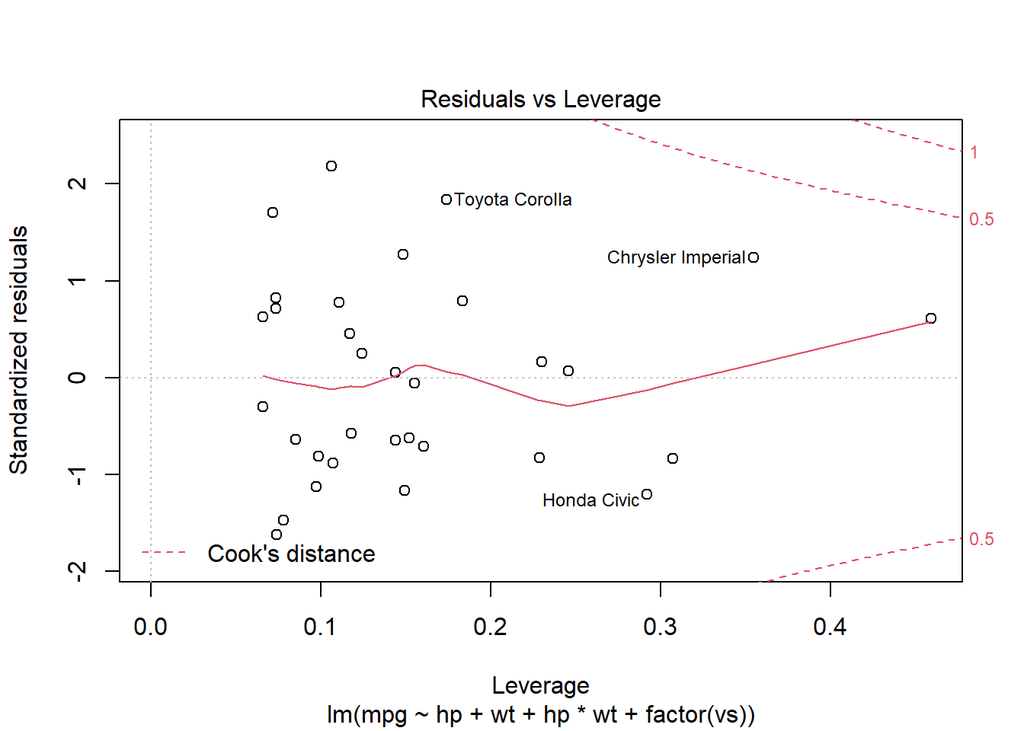

```r
plot(fit)
```

# 4 Hypothesis Testing

## 4.1 Hypothesis Tests for Population Means

### 4.1.1 One Sample t-test

Ho:

- Two-Sided: The population mean is equal to a fixed or known value
- One-Sided: The population mean is no greater than a fixed or known value
- One-Sided: The population mean is no less than a fixed or known value

Examples below use a significance level of 0.05.

The alternative hypothesis, must be one of “two.sided” (default), “greater” or “less”. You can specify just the initial letter.

```r
t.test(test.data, mu=0, alternative="two.sided",conf.level = 0.95)
```

```
##
##  One Sample t-test
##
## data:  test.data
## t = -1.227, df = 49, p-value = 0.2257
## alternative hypothesis: true mean is not equal to 0
## 95 percent confidence interval:
##  -0.38025787  0.09194878
## sample estimates:
##  mean of x
## -0.1441545
```

```r
t.test(test.data, mu=0, alternative="greater",conf.level = 0.95)
```

```
##
##  One Sample t-test
##
## data:  test.data
## t = -1.227, df = 49, p-value = 0.8871
## alternative hypothesis: true mean is greater than 0
## 95 percent confidence interval:
##  -0.3411311        Inf
## sample estimates:
##  mean of x
## -0.1441545
```

```r
t.test(test.data, mu=0, alternative="less",conf.level = 0.95)
```

```
##
##  One Sample t-test
##
## data:  test.data
## t = -1.227, df = 49, p-value = 0.1129
## alternative hypothesis: true mean is less than 0
## 95 percent confidence interval:
##        -Inf 0.05282203
## sample estimates:
##  mean of x
## -0.1441545
```

Print the confidence intervals:

```r
ttest1 <- t.test(test.data, mu=0, alternative="two.sided",conf.level = 0.95)

ttest1$conf.int
```

```
## [1] -0.38025787  0.09194878
## attr(,"conf.level")
## [1] 0.95
```

### 4.1.2 Two Sample t-test

First of all, create a sample dataset for Two Sample t-test.

```r
## generate two vectors of normally distributed values

group1 <- rnorm( 20,mean=0,sd=1 )
group2 <- rnorm( 20,mean=1,sd=1.2 )

group1
```

```
##  [1]  2.06582710  0.32822049  1.40536860 -0.64843559 -0.21819217  1.21447923
##  [7] -1.64178653 -0.22457334 -0.93995272 -1.04213389  1.36194244 -1.81630347
## [13] -0.21149546 -0.67241715 -1.09835778 -0.47096782  0.77200130  1.89636129
## [19]  1.86991678  0.05580499
```

```r
group2
```

```
##  [1]  1.5876560  0.7884791 -0.2425025  2.5681660  3.2924661  0.2445937
##  [7]  0.9931354  2.4981913  0.6724110 -0.1801932  1.5379934  1.2500061
## [13]  0.8559587  0.4649800  3.2091998 -0.1184712  1.1209571  0.3180431
## [19] -0.2215285  3.3819650
```

```r
## append two groups into a data frame

data1 <- data.frame(value=c(group1,group2),
                    group=c(rep(1,length(group1)),rep(2,length(group2))))

data1
```

```
##          value group
## 1   2.06582710     1
## 2   0.32822049     1
## 3   1.40536860     1
## 4  -0.64843559     1
## 5  -0.21819217     1
## 6   1.21447923     1
## 7  -1.64178653     1
## 8  -0.22457334     1
## 9  -0.93995272     1
## 10 -1.04213389     1
## 11  1.36194244     1
## 12 -1.81630347     1
## 13 -0.21149546     1
## 14 -0.67241715     1
```

[output cut: 26 more lines]

Ho:

- Two-Sided: The difference between the means of the first population and the second population is equal to 0.
- One-Sided: The difference between the means of the first population and the second population is no greater than 0.
- One-Sided: The difference between the means of the first population and the second population is no less than 0.

Examples below use a significance level of 0.05.

The alternative hypothesis, must be one of “two.sided” (default), “greater” or “less”. You can specify just the initial letter.

```r
## Method 1

t.test(value~group, data=data1, alternative="two.sided", conf.level = 0.95, var.equal=T)
```

```
##
##  Two Sample t-test
##
## data:  value by group
## t = -2.8916, df = 38, p-value = 0.006308
## alternative hypothesis: true difference in means is not equal to 0
## 95 percent confidence interval:
##  -1.8731934 -0.3304266
## sample estimates:
## mean in group 1 mean in group 2
##      0.09926532      1.20107532
```

```r
## Method 2

t.test(group1,group2, alternative="two.sided", conf.level = 0.95, var.equal=T )
```

```
##
##  Two Sample t-test
##
## data:  group1 and group2
## t = -2.8916, df = 38, p-value = 0.006308
## alternative hypothesis: true difference in means is not equal to 0
## 95 percent confidence interval:
##  -1.8731934 -0.3304266
## sample estimates:
##  mean of x  mean of y
## 0.09926532 1.20107532
```

### 4.1.3 Paired t-test

Ho:

- Two-Sided: The paired mean difference is equal to 0.
- One-Sided: The paired mean difference is no greater than 0.
- One-Sided: The paired mean difference is no less than 0.

Examples below use a significance level of 0.05.

The alternative hypothesis, must be one of “two.sided” (default), “greater” or “less”. You can specify just the initial letter.

```r
# Method 1
t.test(value~group, data=data1, alternative="two.sided",conf.level = 0.95, paired = T)
```

```
##
##  Paired t-test
##
## data:  value by group
## t = -2.5897, df = 19, p-value = 0.01797
## alternative hypothesis: true difference in means is not equal to 0
## 95 percent confidence interval:
##  -1.9922884 -0.2113316
## sample estimates:
## mean of the differences
##                -1.10181
```

```r
# or Method 2
# t.test(group1,group2, alternative="two.sided",conf.level = 0.95, paired = T)
```

### 4.1.4 Two One-Sided T-Test (TOST)

Ho: The absolute difference between the means of the first and second populations is greater than or equal to the equivalence limit (epsilon).

Ha: The absolute difference between the means of the first and second populations is less than the equivalence limit (epsilon).

Examples below use a significance level of 0.05.

```r
library(equivalence)

tost(group1, group2, epsilon = 2, paired = F, var.equal = T, conf.level = 0.95)
```

```
##
##  Two Sample TOST
##
## data:  group1 and group2
## df = 38
## sample estimates:
##  mean of x  mean of y
## 0.09926532 1.20107532
##
## Epsilon: 2
## 95 percent two one-sided confidence interval (TOST interval):
##  -1.744233 -0.459387
## Null hypothesis of statistical difference is: rejected
## TOST p-value: 0.01183405
```

Print the confidence intervals:

```r
tostsum <- tost(group1, group2, epsilon = 2, paired = F, var.equal = T, conf.level = 0.95)
tostsum$tost.interval
```

```
## [1] -1.744233 -0.459387
## attr(,"conf.level")
## [1] 0.95
```

## 4.2 Hypothesis Tests for Population Variances

The F-test is used to determine whether the variance of one population is statistically significantly different from the variance of another population.

Ho:

- Two-Sided: The variance of the first population is equal to the variance of the second population.
- One-Sided: The variance of the first population is no greater than the variance of the second population.
- One-Sided: The variance of the first population is no less than the variance of the second population.

Examples below use a significance level of 0.05.

The alternative hypothesis, must be one of “two.sided” (default), “greater” or “less”. You can specify just the initial letter.

```r
# Method 1
var.test(value ~ group, data1, alternative = "two.sided", conf.level = 0.95)
```

```
##
##  F test to compare two variances
##
## data:  value by group
## F = 0.99969, num df = 19, denom df = 19, p-value = 0.9995
## alternative hypothesis: true ratio of variances is not equal to 1
## 95 percent confidence interval:
##  0.3956879 2.5256575
## sample estimates:
## ratio of variances
##           0.999686
```

```r
# or Method 2
# var.test(group1, group2, alternative = "two.sided")
```

Print the confidence intervals:

```r
vartest1 <- var.test(value ~ group, data1, alternative = "two.sided", conf.level = 0.95)

vartest1$conf.int
```

```
## [1] 0.3956879 2.5256575
## attr(,"conf.level")
## [1] 0.95
```

## 4.3 Hypothesis Tests for Population Proportions

### 4.3.1 One-Sample Proportion Test

Ho:

- Two-Sided: The population proportion is equal to a fixed or known value.
- One-Sided: The population proportion is no greater than a fixed or known value.
- One-Sided: The population proportion is no less than a fixed or known value.

Examples below use a significance level of 0.05.

The alternative hypothesis, must be one of “two.sided” (default), “greater” or “less”. You can specify just the initial letter.

```r
# x: counts of successes
# n: counts of trials

# Is the true probabilities of success 0.5 ?
prop.test(x=12, n=20, p=0.5, alternative = "two.sided",conf.level=0.95)
```

```
##
##  1-sample proportions test with continuity correction
##
## data:  12 out of 20, null probability 0.5
## X-squared = 0.45, df = 1, p-value = 0.5023
## alternative hypothesis: true p is not equal to 0.5
## 95 percent confidence interval:
##  0.3641167 0.8002291
## sample estimates:
##   p
## 0.6
```

```r
#Exact Binomial Test
binom.test(x=12,n=20,p=0.5, alternative = "two.sided",conf.level=0.95)
```

```
##
##  Exact binomial test
##
## data:  12 and 20
## number of successes = 12, number of trials = 20, p-value = 0.5034
## alternative hypothesis: true probability of success is not equal to 0.5
## 95 percent confidence interval:
##  0.3605426 0.8088099
## sample estimates:
## probability of success
##                    0.6
```

### 4.3.2 Two-Sample Proportion Test

For example, group A won 11 out of 20 games, group B won 12 out of 25 games. Is there a significant difference between both ratios?

Ho:

- Two-Sided: The first population proportion is equal to the second population proportion.
- One-Sided: The first population proportion is no greater than the second population proportion.
- One-Sided: The first population proportion is no less than the second population proportion.

Examples below use a significance level of 0.05.

The alternative hypothesis, must be one of “two.sided” (default), “greater” or “less”. You can specify just the initial letter.

```r
# two-proportions z-test
prop.test(x=c(11,12), n=c(20,25), alternative = "two.sided")
```

```
##
##  2-sample test for equality of proportions with continuity correction
##
## data:  c(11, 12) out of c(20, 25)
## X-squared = 0.027792, df = 1, p-value = 0.8676
## alternative hypothesis: two.sided
## 95 percent confidence interval:
##  -0.268072  0.408072
## sample estimates:
## prop 1 prop 2
##   0.55   0.48
```

```r
# Fisher's Exact Test
fisher.test(
  matrix(c(11,20-11,
           12, 25-12), ncol=2)
  )
```

```
##
##  Fisher's Exact Test for Count Data
##
## data:  matrix(c(11, 20 - 11, 12, 25 - 12), ncol = 2)
## p-value = 0.7666
## alternative hypothesis: true odds ratio is not equal to 1
## 95 percent confidence interval:
##  0.3491989 5.0623337
## sample estimates:
## odds ratio
##   1.315801
```

# 5 Statistical Intervals

## 5.1 Nonparametric Sample Intervals

Nonparametric sample intervals use quantiles to set the limits or bounds.

```r
quantile(test.data,prob=c(0.01,0.1,0.25,0.5,0.75,0.9,0.99))
```

```
##         1%        10%        25%        50%        75%        90%        99%
## -1.9037159 -1.5170137 -0.5096181 -0.1436972  0.4782551  0.8588456  1.3468758
```

## 5.2 Confidence Intervals

(Introduced in previous sections.)

## 5.3 Tolerance Intervals

For example, calculate a 95% tolerance interval for 90% of the data.

```r
# The package "tolerance" can create tolerance intervals
# install.packages("tolerance")
library(tolerance)

normtol.int(test.data,
            alpha = 0.05,   ## 95% confidence interval
            P = 0.90,       ## 90% coverage
            side = 2        ## 2-sided
            )
```

```
##   alpha   P      x.bar 2-sided.lower 2-sided.upper
## 1  0.05 0.9 -0.1441545     -1.804732      1.516423
```

# 6 Resources

- BQ-REF-000011
- Essential R: What you need to get started
- R Markdown: The Definitive Guide (https://bookdown.org/yihui/rmarkdown/)